# Improvement of Prediction Performance with Conjoint Molecular Fingerprint in Deep Learning

**Introduction**:

Accurately predicting the physical properties and bioactivity of drug molecules is crucial in drug development. To achieve this goal, researchers have developed various molecular descriptors for quantitative structure-activity/property relationships (QSPR). However, each descriptor is optimized for specific applications, resulting in encoding preferences.

**Methods and Problem**:

Recognizing that standalone featurization methods may only capture partial information of chemical molecules, the study proposes the construction of a conjoint fingerprint by combining two complementary fingerprints. The impact of the conjoint fingerprint and each standalone fingerprint on prediction performance was systematically evaluated using machine learning/deep learning methods such as random forest, support vector regression, extreme gradient boosting, long short-term memory network, and deep neural network. The results demonstrated that the conjoint fingerprint yielded improved predictive performance, even surpassing the consensus model using two standalone fingerprints in four out of five examined methods. The proposed conjoint fingerprint scheme exhibits easy extensibility and high applicability, offering new opportunities to enhance the predictive performance of deep learning by harnessing the complementarity of various fingerprint types.

**Conclusions**:

This research has significant implications for the field of drug discovery and deep learning. By enhancing the prediction performance of drug molecule properties, this method has the potential to expedite the drug discovery process and provide more opportunities and choices for drug development. The findings open up new avenues for the application of artificial intelligence and deep learning in the pharmaceutical industry and offer insights for researchers in other fields.

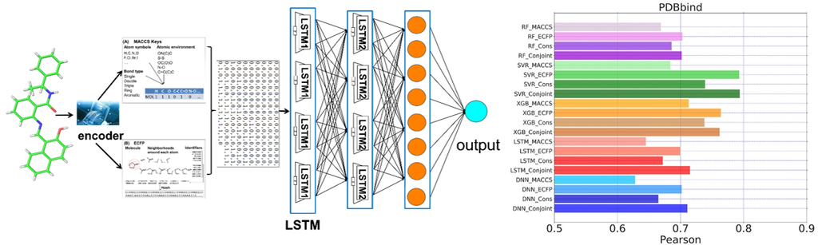

**简介**：

在药物研发中，准确预测药物分子的物理性质和生物活性非常重要。为了实现这一目标，研究人员开发了许多用于定量构效关系（QSPR）的分子描述符。然而，每种分子描述符都针对特定应用进行了优化，具有编码偏好。

**方法和问题**：

考虑到独立的特征化方法可能只涵盖了化学分子信息的一部分，研究人员提出通过组合两种补充的分子指纹来构建联合指纹。他们系统评估了联合指纹和每种独立指纹在预测蛋白质-配体的分配系数（logP）和结合亲和力方面的性能，并使用机器学习/深度学习方法（包括随机森林、支持向量回归、极限梯度提升、长短期记忆网络和深度神经网络）进行了比较。 研究结果表明，联合指纹在预测性能上表现出色，甚至超过了使用两个独立指纹的共识模型。由于联合指纹方案具有易扩展性和高适用性，研究人员预计这种方法将为深度学习的预测性能提供新的机会，通过利用各种类型指纹的互补性来不断改进。

**结论**：

这项研究的成果对于药物领域和深度学习研究具有重要意义。通过改进药物分子性质的预测性能，这种方法有望加速药物发现过程，为药物研发提供更多的机会和选择。这项研究为药物领域的人工智能和深度学习应用开辟了新的道路，也为其他领域的研究者提供了借鉴和启示。

Return to Research.